# Intro to Stan

# 3. Evaluate the model fit

- Traceplots can tell you about model convergence and efficiency
- Histograms can alert you to problems with multi-modality
- Run multiple chains to help with diagnostics

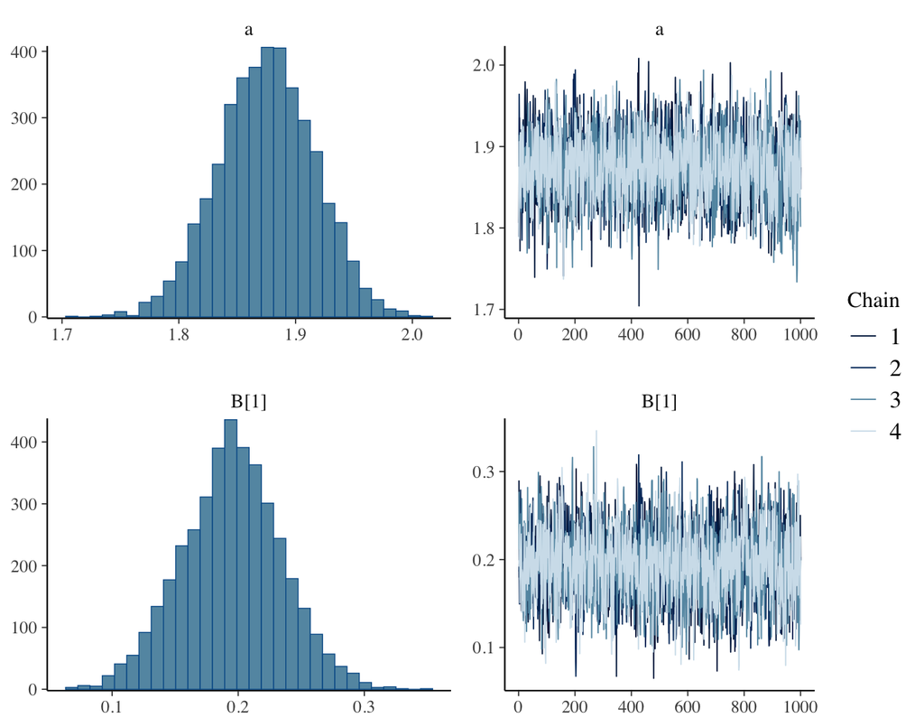

```r
## Use as.array if you want to keep different mcmc chains together
## This is ideal for diagnostics
## For inference, you usually want to lump all chains
## In this case, you use as.matrix
samp1_pars = as.array(fit1, pars=c('a', 'B'))
mcmc_combo(samp1_pars, c("hist", "trace"))
```

- Printing the model also gives useful metrics
- Can filter by parameters of interest
- n_eff: Effective sample size (after removing autocorrelation)
  - This gives you an indication of how much precision in the tails of the posterior you have
- Rhat: convergence diagnostic, available with multiple chains
  - ideally, Rhat = 1
  - Worry about for “real” parameters (not hierarchical, not deterministic)
  - Rhat > 1.1 for a real parameter is a problem
  - Rhat < 1.05 is probably ok

```r
print(fit1, pars = c('a', 'B'))
## Inference for Stan model: 5c0b16bbee48bcf4a957b09a484d1746.
## 4 chains, each with iter=2000; warmup=1000; thin=1;
## post-warmup draws per chain=1000, total post-warmup draws=4000.
##
##      mean se_mean   sd 2.5%  25%  50%  75% 97.5% n_eff Rhat
## a    1.88       0 0.04 1.79 1.85 1.88 1.90  1.95  2538    1
## B[1] 0.19       0 0.04 0.12 0.17 0.20 0.22  0.27  2637    1
##
## Samples were drawn using NUTS(diag_e) at Thu Nov 24 14:14:36 2022.
## For each parameter, n_eff is a crude measure of effective sample size,
## and Rhat is the potential scale reduction factor on split chains (at
## convergence, Rhat=1).
```

# 4. Inference: parameter estimates

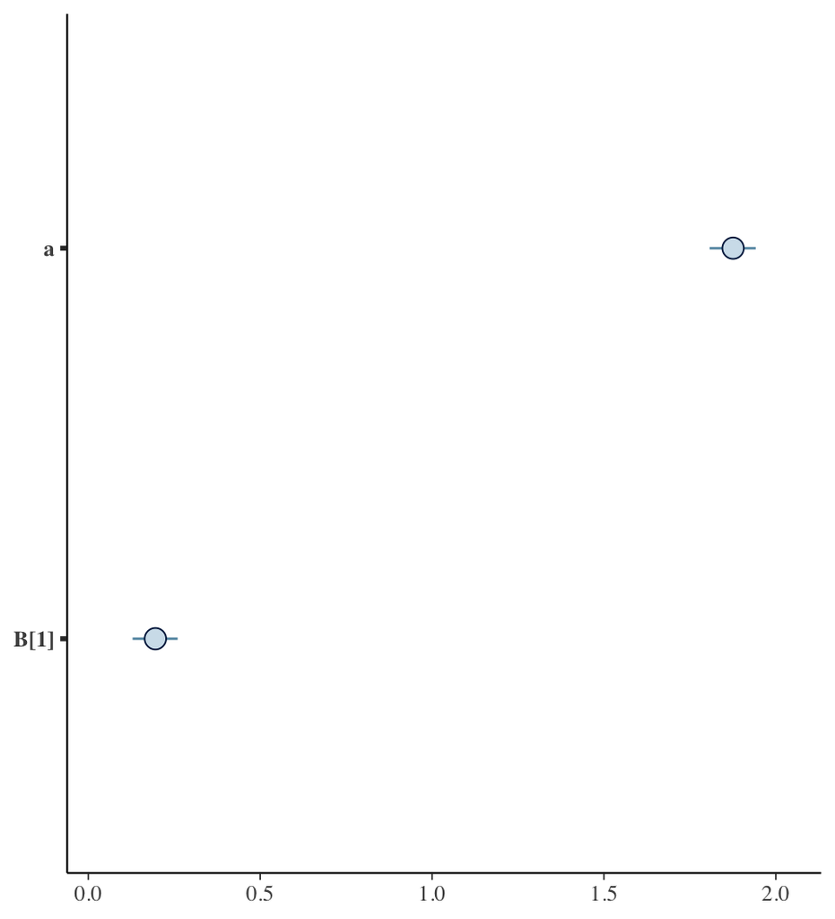

```r
mcmc_intervals(samp1_pars)
```

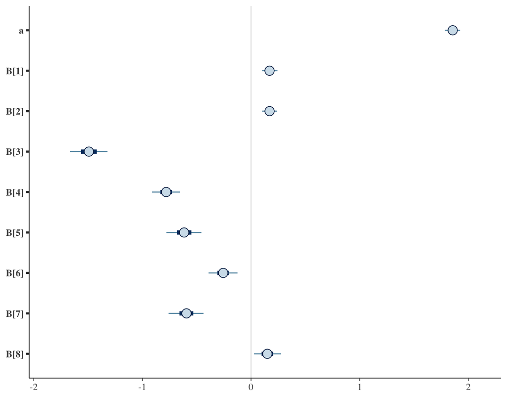

```r
samp2_pars = as.array(fit2, pars=c('a', 'B'))
mcmc_intervals(samp2_pars)
```

# 4. Inference: Retrodiction

- How close is the model to the original data?
- How well does our generative model describe the data

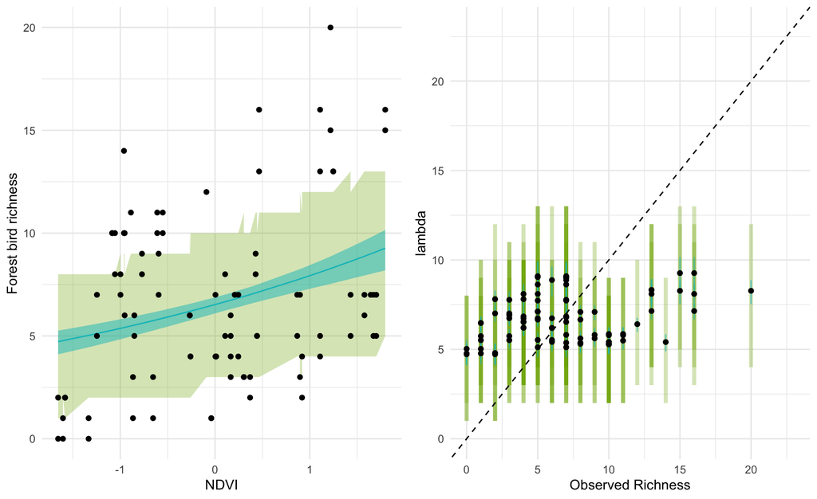

```r
# compute posterior distribution of the residual sum of squares
samp1_lam = as.matrix(fit1, pars='lambda')
sq_resid1 = apply(samp1_lam, 1, function(x) (standat1$richness - x)^2)

# compute posterior distribution of dispersion parameter, which is just
# sum(squared residuals)/(n - k)
# here k is 2, we have an intercept and one slope
# if phi > 1, we have overdispersion and need a better model
phi = apply(sq_resid1, 2, function(x) sum(x)/(length(x) - 2))
quantile(phi, c(0.5, 0.05, 0.95))
##      50%       5%      95%
## 16.48539 16.39336 16.83240
```

# 4. Inference: Improve the model

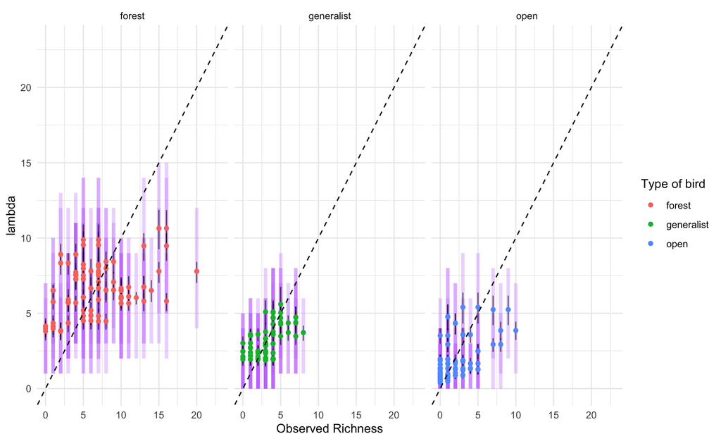

```r
# compute posterior distribution of the residual sum of squares
samp2_lam = as.matrix(fit2, pars='lambda')
sq_resid2 = apply(samp2_lam, 1, function(x) (standat2$richness - x)^2)

# compute posterior distribution of dispersion parameter, which is just
# sum(squared residuals)/(n - k)
# here k is 2, we have an intercept and one slope
# if phi > 1, we have overdispersion and need a better model
phi = apply(sq_resid2, 2, function(x) sum(x)/(length(x) - 2))
quantile(phi, c(0.5, 0.05, 0.95))
##      50%       5%      95%
## 7.476215 7.382057 7.665440
```

- This model is still quite overdispersed
  - Consider more variables
  - Consider other likelihoods (e.g., Negative Binomial)

# 4. Inference: Partial Response Curves

- How does richness respond to the individual variables, holding other variables constant?

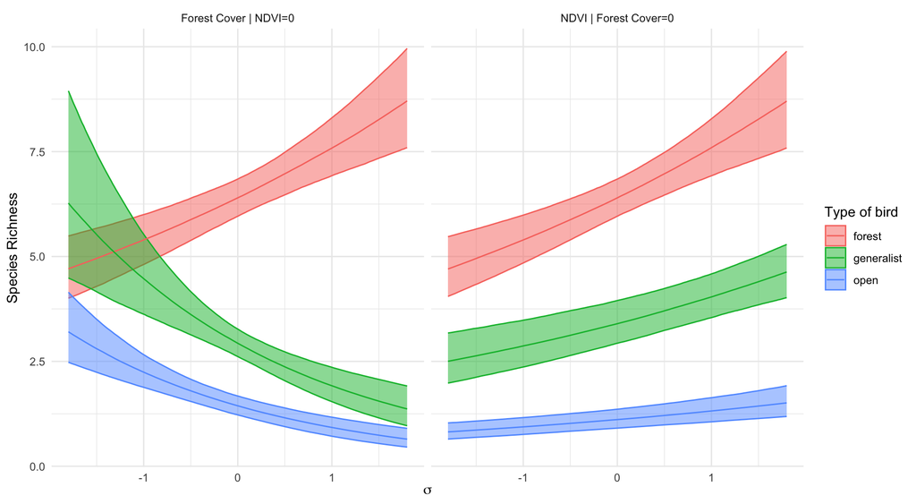

# 4. Inference: Response Surfaces

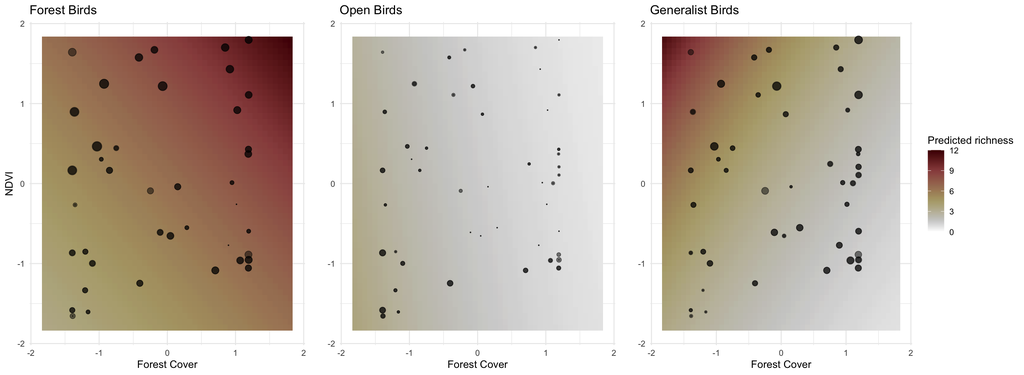